# some_markdown slides

Hashtables are basically an array that links a key to a specific data value(s), where each key is unique. They are data structure that efficiently implements search/lookup operations. It aims to divide the whole search space into well-defined regions, so we don’t have to search linearly through the entire collection to find an element.

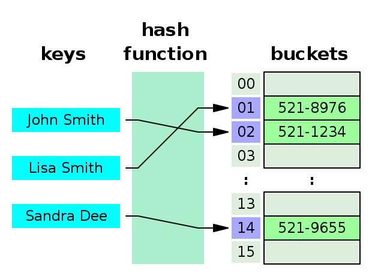

Hashtable Techniques -

- Hashing
- Hash function  
  Key values are converted to integer values using **hashing technique**. And we use the **hash function** to find the required key-value pair. So, we reduce the search time from linearly to directly searching in the bucket.

Ideally for **perfect hashing** we have only 1 value for each array index. So that we can directly find the index after hashing and get a time complexity of O(1).  
This is practically **impossible.**

[figure not shown]

#### Seperate hashing

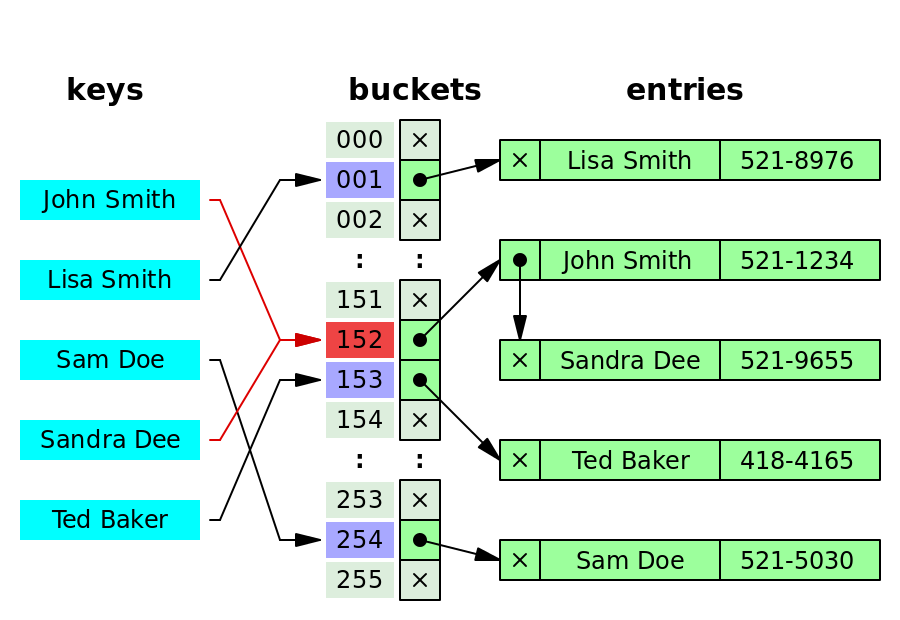

Ex 1 : Google search Google Search is a fully-automated search engine that uses software known as web crawlers that explore the web regularly to find pages to add to our index. It also filters out the duplicate web pages based on html tags and other parameters. ---- Complicated version of a hashtable

To give you the most useful information, Search algorithms look at many factors and signals, including the words of your query, relevance and usability of pages, expertise of sources, and your location and settings. The weight applied to each factor varies depending on the nature of your query.

*source: https://developers.google.com/search/docs/fundamentals/how-search-works*